# capston project

### import modules

```python
import pandas as pd
import numpy as np
import matplotlib.pyplot as plt
import seaborn as sns
import warnings
import warnings
warnings.filterwarnings("ignore")
```

### Read csv file

```python
dataframe=pd.read_csv("D:\91951\Downloads\Hotel Bookings.csv")
```

### Creating a copy file as df

```python
df=dataframe.copy()
```

```python
df.head()
```

|  | hotel | is_canceled | lead_time | arrival_date_year | arrival_date_month | arrival_date_week_number | arrival_date_day_of_month | stays_in_weekend_nights | stays_in_week_nights | adults | ... | deposit_type | agent | company | days_in_waiting_list | customer_type | adr | required_car_parking_spaces | total_of_special_requests | reservation_status | reservation_status_date |
| --- | --- | --- | --- | --- | --- | --- | --- | --- | --- | --- | --- | --- | --- | --- | --- | --- | --- | --- | --- | --- | --- |
| 0 | Resort Hotel | 0 | 342 | 2015 | July | 27 | 1 | 0 | 0 | 2 | ... | No Deposit | NaN | NaN | 0 | Transient | 0.0 | 0 | 0 | Check-Out | 2015-07-01 |
| 1 | Resort Hotel | 0 | 737 | 2015 | July | 27 | 1 | 0 | 0 | 2 | ... | No Deposit | NaN | NaN | 0 | Transient | 0.0 | 0 | 0 | Check-Out | 2015-07-01 |
| 2 | Resort Hotel | 0 | 7 | 2015 | July | 27 | 1 | 0 | 1 | 1 | ... | No Deposit | NaN | NaN | 0 | Transient | 75.0 | 0 | 0 | Check-Out | 2015-07-02 |
| 3 | Resort Hotel | 0 | 13 | 2015 | July | 27 | 1 | 0 | 1 | 1 | ... | No Deposit | 304.0 | NaN | 0 | Transient | 75.0 | 0 | 0 | Check-Out | 2015-07-02 |
| 4 | Resort Hotel | 0 | 14 | 2015 | July | 27 | 1 | 0 | 2 | 2 | ... | No Deposit | 240.0 | NaN | 0 | Transient | 98.0 | 0 | 1 | Check-Out | 2015-07-03 |

5 rows × 32 columns

```python
df.columns
```

```
Index(['hotel', 'is_canceled', 'lead_time', 'arrival_date_year',
       'arrival_date_month', 'arrival_date_week_number',
       'arrival_date_day_of_month', 'stays_in_weekend_nights',
       'stays_in_week_nights', 'adults', 'children', 'babies', 'meal',
       'country', 'market_segment', 'distribution_channel',
       'is_repeated_guest', 'previous_cancellations',
       'previous_bookings_not_canceled', 'reserved_room_type',
       'assigned_room_type', 'booking_changes', 'deposit_type', 'agent',
       'company', 'days_in_waiting_list', 'customer_type', 'adr',
       'required_car_parking_spaces', 'total_of_special_requests',
       'reservation_status', 'reservation_status_date'],
      dtype='object')
```

```python
df.info()
```

```
<class 'pandas.core.frame.DataFrame'>
RangeIndex: 119390 entries, 0 to 119389
Data columns (total 32 columns):
 #   Column                          Non-Null Count   Dtype
---  ------                          --------------   -----
 0   hotel                           119390 non-null  object
 1   is_canceled                     119390 non-null  int64
 2   lead_time                       119390 non-null  int64
 3   arrival_date_year               119390 non-null  int64
 4   arrival_date_month              119390 non-null  object
 5   arrival_date_week_number        119390 non-null  int64
 6   arrival_date_day_of_month       119390 non-null  int64
 7   stays_in_weekend_nights         119390 non-null  int64
 8   stays_in_week_nights            119390 non-null  int64
 9   adults                          119390 non-null  int64
```

[output cut: 24 more lines]

```python
df.describe()
```

|  | is_canceled | lead_time | arrival_date_year | arrival_date_week_number | arrival_date_day_of_month | stays_in_weekend_nights | stays_in_week_nights | adults | children | babies | is_repeated_guest | previous_cancellations | previous_bookings_not_canceled | booking_changes | agent | company | days_in_waiting_list | adr | required_car_parking_spaces | total_of_special_requests |
| --- | --- | --- | --- | --- | --- | --- | --- | --- | --- | --- | --- | --- | --- | --- | --- | --- | --- | --- | --- | --- |
| count | 119390.000000 | 119390.000000 | 119390.000000 | 119390.000000 | 119390.000000 | 119390.000000 | 119390.000000 | 119390.000000 | 119386.000000 | 119390.000000 | 119390.000000 | 119390.000000 | 119390.000000 | 119390.000000 | 103050.000000 | 6797.000000 | 119390.000000 | 119390.000000 | 119390.000000 | 119390.000000 |
| mean | 0.370416 | 104.011416 | 2016.156554 | 27.165173 | 15.798241 | 0.927599 | 2.500302 | 1.856403 | 0.103890 | 0.007949 | 0.031912 | 0.087118 | 0.137097 | 0.221124 | 86.693382 | 189.266735 | 2.321149 | 101.831122 | 0.062518 | 0.571363 |
| std | 0.482918 | 106.863097 | 0.707476 | 13.605138 | 8.780829 | 0.998613 | 1.908286 | 0.579261 | 0.398561 | 0.097436 | 0.175767 | 0.844336 | 1.497437 | 0.652306 | 110.774548 | 131.655015 | 17.594721 | 50.535790 | 0.245291 | 0.792798 |
| min | 0.000000 | 0.000000 | 2015.000000 | 1.000000 | 1.000000 | 0.000000 | 0.000000 | 0.000000 | 0.000000 | 0.000000 | 0.000000 | 0.000000 | 0.000000 | 0.000000 | 1.000000 | 6.000000 | 0.000000 | -6.380000 | 0.000000 | 0.000000 |
| 25% | 0.000000 | 18.000000 | 2016.000000 | 16.000000 | 8.000000 | 0.000000 | 1.000000 | 2.000000 | 0.000000 | 0.000000 | 0.000000 | 0.000000 | 0.000000 | 0.000000 | 9.000000 | 62.000000 | 0.000000 | 69.290000 | 0.000000 | 0.000000 |
| 50% | 0.000000 | 69.000000 | 2016.000000 | 28.000000 | 16.000000 | 1.000000 | 2.000000 | 2.000000 | 0.000000 | 0.000000 | 0.000000 | 0.000000 | 0.000000 | 0.000000 | 14.000000 | 179.000000 | 0.000000 | 94.575000 | 0.000000 | 0.000000 |
| 75% | 1.000000 | 160.000000 | 2017.000000 | 38.000000 | 23.000000 | 2.000000 | 3.000000 | 2.000000 | 0.000000 | 0.000000 | 0.000000 | 0.000000 | 0.000000 | 0.000000 | 229.000000 | 270.000000 | 0.000000 | 126.000000 | 0.000000 | 1.000000 |
| max | 1.000000 | 737.000000 | 2017.000000 | 53.000000 | 31.000000 | 19.000000 | 50.000000 | 55.000000 | 10.000000 | 10.000000 | 1.000000 | 26.000000 | 72.000000 | 21.000000 | 535.000000 | 543.000000 | 391.000000 | 5400.000000 | 8.000000 | 5.000000 |

```python
df.shape
```

```
(119390, 32)
```

### Data cleaning and visualizations

```python
df["hotel"].value_counts()
```

```
City Hotel      79330
Resort Hotel    40060
Name: hotel, dtype: int64
```

### Hotels

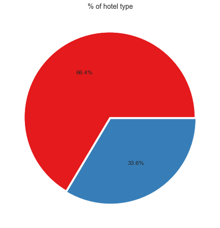

```python
plt.pie(df["hotel"].value_counts(),explode=[0.01, 0.01], autopct='%1.1f%%')
plt.title(" % of hotel type ",fontsize=14);
```

#### 66.4% City hotel and 33.6% Resort Hotel

### which hotel has hightest lead Time

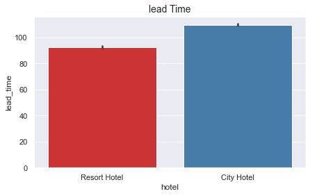

```python
plt.figure(figsize=(7,4))
graph=sns.barplot(x=df["hotel"],y=df["lead_time"])
graph.set_title("lead Time",fontsize=14);
```

### lead Time :

The number of days between the time a guest books their room and the time they are scheduled to arrive at the hotel.

City Hotel is the Highest Lead Time

```
(0.0, 600.0)
```

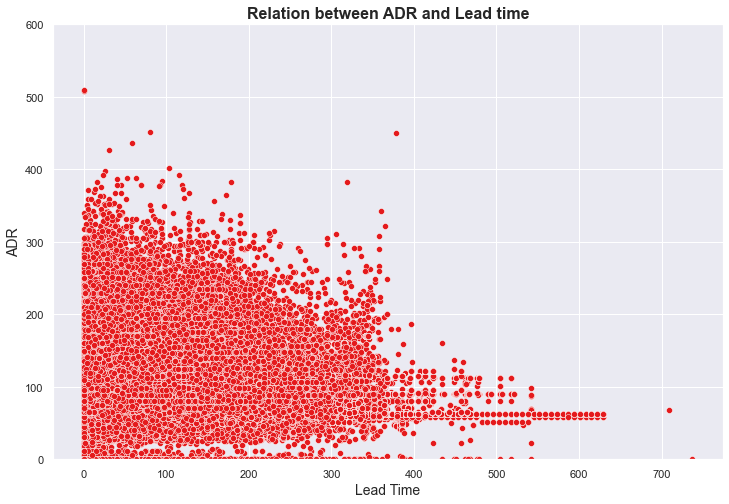

```python
graph = sns.scatterplot(data = df, x = 'lead_time', y = 'adr')
graph.set_title('Relation between ADR and Lead time',fontsize = 16, fontweight='bold')
graph.set_xlabel('Lead Time',fontsize = 14)
graph.set_ylabel('ADR',fontsize = 14)
graph.set_ylim(0,600)
```

### which year has highest arrival_date

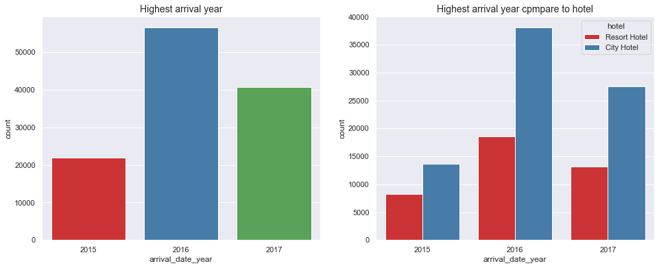

```python
figure,axes=plt.subplots(1, 2,figsize=(16,6))

graph=sns.countplot(x=df["arrival_date_year"],ax=axes[0])

graph1=sns.countplot(x=df["arrival_date_year"],data=df,hue='hotel',ax=axes[1]);
graph.set_title('Highest arrival year',fontsize=14)
graph1.set_title('Highest arrival year cpmpare to hotel',fontsize=14);
```

### Highest arrival year

2016 is the Highest arrival year

City Hotel is having Highest Arrival rate in all three years

### which month was highest arrival_date

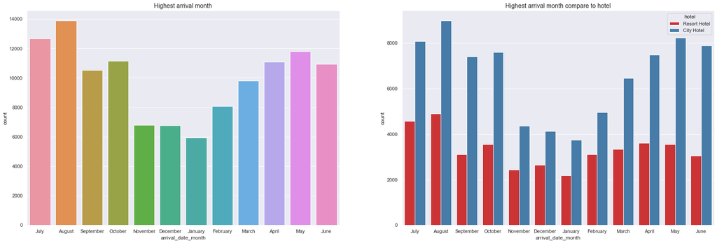

```python
figure,axes=plt.subplots(1,2,figsize=(28,9))
graph=sns.countplot(x=df["arrival_date_month"],ax=axes[0])
graph1=sns.countplot(x=df["arrival_date_month"],data=df,hue='hotel',ax=axes[1])
graph.set_title('Highest arrival month',fontsize=14)
graph1.set_title('Highest arrival month compare to hotel',fontsize=14);
```

Customer Arrival is high in August month in all the years of the data

The customer Arrival rate is high in City Hotel than in Resort Hotel August month in all the years of the data

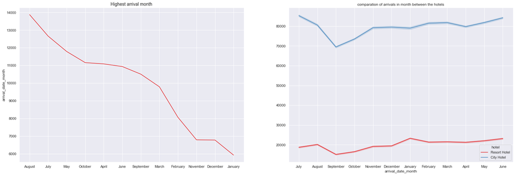

```python
month=pd.DataFrame(df["arrival_date_month"].value_counts())
plt.figure(figsize=(11,6))
figure,axes=plt.subplots(1,2,figsize=(28,9))
graph=sns.lineplot(x=month.index,y=month["arrival_date_month"],ax=axes[0])
graph.set_title('Highest arrival month',fontsize=14)
graph1=sns.lineplot(y=df['arrival_date_month'].index,x=df['arrival_date_month'],hue="hotel",data=df,ax=axes[1])
graph1.set_title("comparation of arrivals in month between the hotels");
```

##### line graph for Highest arrival month

### most people stay in nights

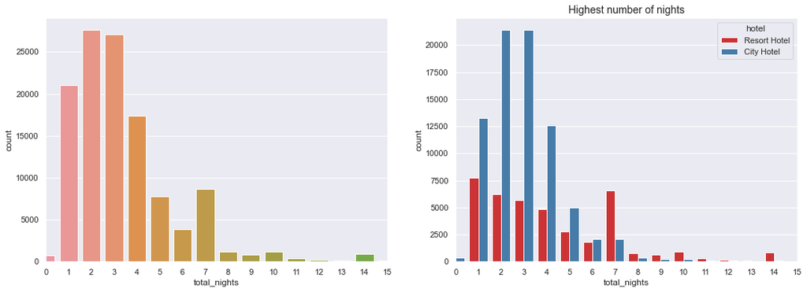

```python
df["total_nights"]=df["stays_in_weekend_nights"]+df["stays_in_week_nights"]
fig,axes=plt.subplots(1,2,figsize=(18,6))
graph=sns.countplot(df["total_nights"],hue='hotel',data=df,ax=axes[1])
graph.set_title('Highest number of nights',fontsize=14)
graph1=sns.countplot(df["total_nights"],ax=axes[0])
graph.set_xlim(0,15)
graph1.set_xlim(0,15);
```

People wish for a night stay in a hotel for 2 to 3 days rather than a week or more

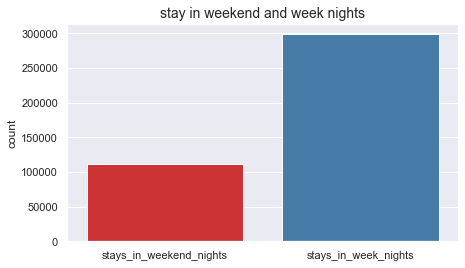

```python
x=df["stays_in_weekend_nights"].sum()
y=df["stays_in_week_nights"].sum()
r=[x,y]
r=pd.Series(r).rename(index={0:"stays_in_weekend_nights",1:"stays_in_week_nights"})
plt.figure(figsize=(7,4))
graph=sns.barplot(x=r.index,y=r)
graph.set_title('stay in weekend and week nights',fontsize=14)
graph.set_ylabel('count');
```

People prefer night stays during Weeks than weekend nights.

```python
city_Hotel=0
resort_hotel=0
for i in range(len(df)):
    if df.iloc[i]['hotel']=="Resort Hotel":
        if df.iloc[i]["stays_in_weekend_nights"]>0:
            resort_hotel=resort_hotel+1
    else:
        if df.iloc[i]["stays_in_weekend_nights"]>0:
            city_Hotel=city_Hotel+1
RH=(resort_hotel,city_Hotel)
x=pd.DataFrame(RH).rename(columns={0:"count weekend nights"},index={0:"resort hotel",1:"city hotel"})
plt.figure(figsize=(8,6))
sns.barplot(x=x.index,y=x['count weekend nights']);
```

[output not shown]

People prefer to choose City Hotel over Resort Hotel over Week and Weekend Nights

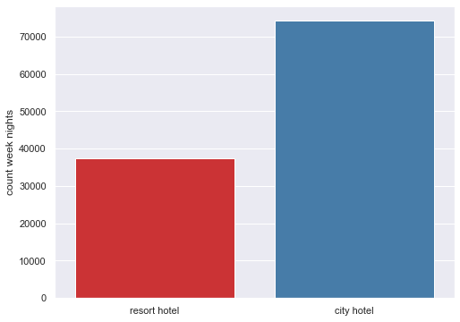

```python
city_Hotell=0
resort_hotell=0
for i in range(len(df)):
    if df.iloc[i]['hotel']=="Resort Hotel":
        if df.iloc[i]["stays_in_week_nights"]>0:
            resort_hotell=resort_hotell+1
    else:
        if df.iloc[i]["stays_in_week_nights"]>0:
            city_Hotell=city_Hotell+1
HR=(resort_hotell,city_Hotell)
y=pd.DataFrame(HR).rename(columns={0:"count week nights"},index={0:"resort hotel",1:"city hotel"})
plt.figure(figsize=(8,6))
sns.barplot(x=y.index,y=y['count week nights']);
```

Also, people prefer to choose City Hotel over Resort Hotel during Week Nights as well

### what type of guest

[figure not shown]

```python
agents=[]
for i in range(len(df)):
    if df.iloc[i]["is_repeated_guest"]==1:
        agent=df.iloc[i]["agent"]
        agents.append(agent)
x=pd.Series(agents).value_counts().nlargest(10)
sns.barplot(x=r.index,y=r)
plt.title('Top 10 repeated Guests')
plt.ylabel("no of times repeated")
plt.xlabel("agents");
```

```python
single=0
couple=0
family=0
for i in range(len(df)):
    if (df.loc[i]['adults']==2) & (df.loc[i]['children']==0) & (df.loc[i]['babies']==0) :
        couple=couple+1
        df["family_type"]="couple"
    elif (df.loc[i]['adults']==1) & (df.loc[i]['children']==0) & (df.loc[i]['babies']==0):
        single=single+1
        df["family_type"]="single"
    elif (df.loc[i]['adults'])+((df.loc[i]['children'])+(df.loc[i]['babies']>2)):
        family=family+1
        df["family_type"]="family"

print(single,couple,family)
```

```
22577 81557 15076
```

```python
p_type=pd.DataFrame((single,couple,family),index=["singles","couple","family"],columns=['count'])
```

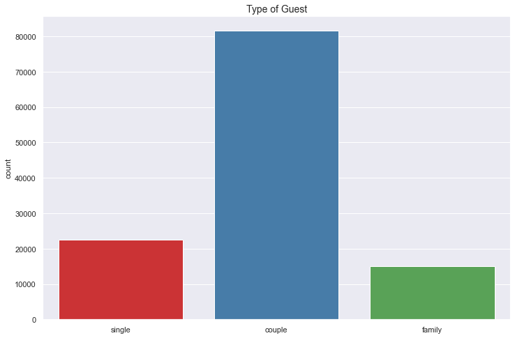

```python
graph=sns.barplot(y=p_type['count'],x=["single","couple",'family'])
graph.set_title('Type of Guest',fontsize=14);
```

This explains the types of customers when grouped with a couple of variables.

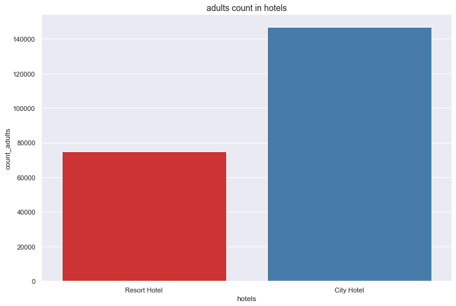

```python
resort_hotel=df[df['hotel']=="Resort Hotel"]
a=resort_hotel["adults"].sum()
city_hotel=df[df['hotel']=="City Hotel"]
b=city_hotel["adults"].sum()
no_adults=pd.Series(data=(a,b),index=["Resort Hotel","City Hotel"])
graph=sns.barplot(x=no_adults.index,y=no_adults)
plt.ylabel('count_adults')
plt.xlabel('hotels')
graph.set_title('adults count in hotels',fontsize=14);
```

### Analysis on Meals

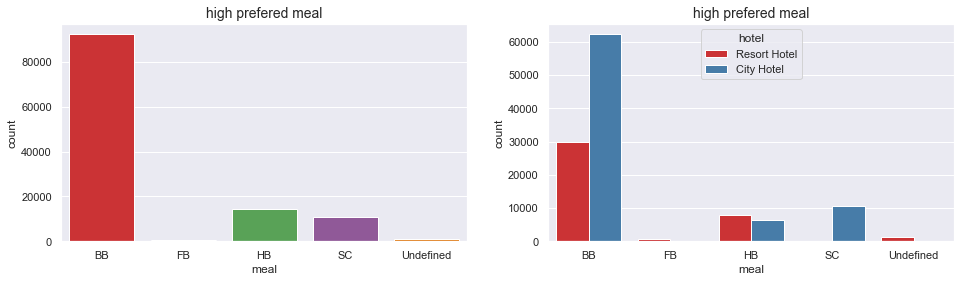

```python
figure,axes=plt.subplots(1,2,figsize=(16,4))
graph=sns.countplot(x=df["meal"],ax=axes[0])
graph1=sns.countplot(x=df["meal"],data=df,hue='hotel',ax=axes[1])
graph.set_title('high prefered meal',fontsize=14)
graph1.set_title('high prefered meal',fontsize=14);
```

most of the peoples prefer BB(Bed,Breakfast) and meal type in both the hotel type.

### Most of the customers visited from top counties

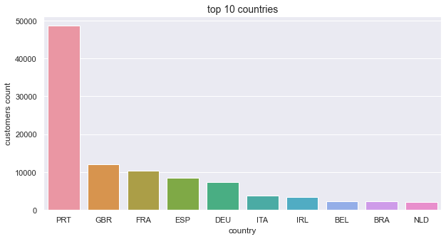

```python
country=(df['country'].value_counts()).head(10)
plt.figure(figsize=(10,5))
sns.barplot(x=country.index,y=country)
plt.title("top 10 countries",fontsize=14)
plt.ylabel('customers count')
plt.xlabel('country');
```

Most of the customers visited from PRT(Portugal) country than the other countries

### Which channel is mostly used for early booking of hotels

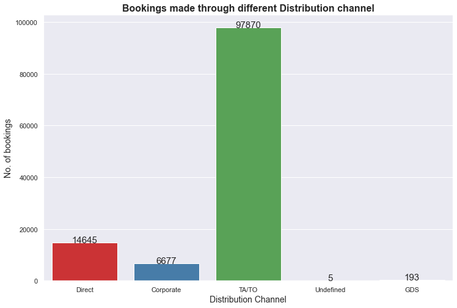

```python
sns.set(rc={'figure.figsize':(12,8)})
sns.set_palette("Set1")
ax = sns.countplot(x='distribution_channel', data=df)
ax.set_title('Bookings made through different Distribution channel',fontsize = 16, fontweight='bold')
ax.set_xlabel('Distribution Channel',fontsize = 14)
ax.set_ylabel('No. of bookings',fontsize = 14)
for rect in ax.patches:
    ax.text (rect.get_x() + rect.get_width()  / 2,rect.get_height()+ 0.20,rect.get_height(),horizontalalignment='center', fontsize = 15);
```

Most of the bookings are done by Travel agencies and Tour Operators for both hotels.

### Distribution channel brings better revenue generating deals for hotels

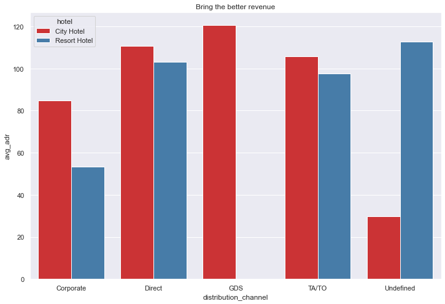

```python
group_by_dc_hotel = df.groupby(['distribution_channel', 'hotel'])
d5 = pd.DataFrame(round((group_by_dc_hotel['adr']).agg(np.mean),2)).reset_index().rename(columns = {'adr': 'avg_adr'})
graph=sns.barplot(x = d5['distribution_channel'], y = d5['avg_adr'], hue = d5['hotel'])
graph.set_title('Bring the better revenue');
```

```python
d5
```

|  | distribution_channel | hotel | avg_adr |
| --- | --- | --- | --- |
| 0 | Corporate | City Hotel | 84.72 |
| 1 | Corporate | Resort Hotel | 53.28 |
| 2 | Direct | City Hotel | 110.81 |
| 3 | Direct | Resort Hotel | 103.07 |
| 4 | GDS | City Hotel | 120.55 |
| 5 | TA/TO | City Hotel | 105.74 |
| 6 | TA/TO | Resort Hotel | 97.45 |
| 7 | Undefined | City Hotel | 29.62 |
| 8 | Undefined | Resort Hotel | 112.70 |

### Price vary

```python
data_resort = df[(df['hotel'] == 'Resort Hotel') & (df['is_canceled'] == 0)]
data_city = df[(df['hotel'] == 'City Hotel') & (df['is_canceled'] == 0)]
resort_hotel = data_resort.groupby(['arrival_date_month'])['adr'].mean().reset_index()
resort_hotel
```

|  | arrival_date_month | adr |
| --- | --- | --- |
| 0 | April | 75.867816 |
| 1 | August | 181.205892 |
| 2 | December | 68.322236 |
| 3 | February | 54.147478 |
| 4 | January | 48.708919 |
| 5 | July | 150.122528 |
| 6 | June | 107.921869 |
| 7 | March | 57.012487 |
| 8 | May | 76.657558 |
| 9 | November | 48.681640 |
| 10 | October | 61.727505 |
| 11 | September | 96.416860 |

[figure not shown]

```python
graph=sns.lineplot(x=resort_hotel['arrival_date_month'],y=resort_hotel['adr'],hue='hotel',data=df)
plt.title("Price Variation based on ADR and Month");
```

price variation between ADR(Average Daily Rate) and customer arrival month

### Canceled hotel percentage

```python
is_cancle=(df["is_canceled"]).value_counts().rename(index={0:'not_cancle',1:'cancled'})
```

```python
is_cancle=pd.DataFrame(is_cancle)
```

```python
is_cancle
```

|  | is_canceled |
| --- | --- |
| not_cancle | 75166 |
| cancled | 44224 |

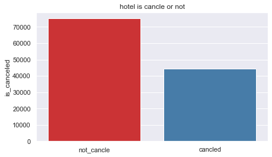

```python
plt.figure(figsize=(7,4))
sns.barplot(x=is_cancle.index,y=is_cancle['is_canceled'])
plt.title('hotel is cancle or not');
```

```python
cancelled= df[df['is_canceled'] == 1]
cancel_grp = cancelled.groupby('hotel')
d1 = pd.DataFrame(cancel_grp.size()).rename(columns = {0:'total_cancelled_bookings'})
grouped_by_hotel = df.groupby('hotel')
total_booking = grouped_by_hotel.size()
d2 = pd.DataFrame(total_booking).rename(columns = {0: 'total_bookings'})
d3 = pd.concat([d1,d2], axis = 1)
d3['cancel_%'] = round((d3['total_cancelled_bookings']/d3['total_bookings'])*100,2)
d3
```

| hotel | total_cancelled_bookings | total_bookings | cancel_% |
| --- | --- | --- | --- |
| City Hotel | 33102 | 79330 | 41.73 |
| Resort Hotel | 11122 | 40060 | 27.76 |

[figure not shown]

```python
plt.figure(figsize=(7,4))
plt.pie(d3['cancel_%'],explode=[0.01, 0.01], autopct='%1.1f%%');
plt.title('cancleation %',fontsize=14);
```

### highest reserved room type

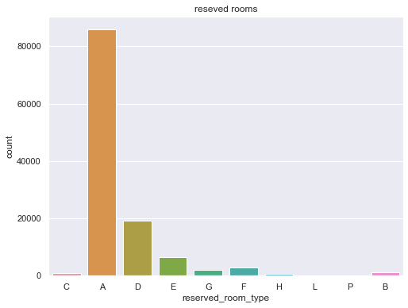

```python
plt.figure(figsize=(8,6))
sns.countplot(df['reserved_room_type'])
plt.title('reseved rooms')
for rect in ax.patches:
    ax.text (rect.get_x() + rect.get_width()  / 2,rect.get_height()+ 0.20,rect.get_height(),horizontalalignment='center', fontsize = 15);
```

### Diposite type

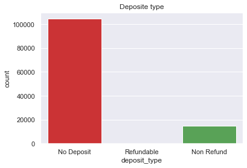

```python
plt.figure(figsize=(6,4))
sns.countplot(df["deposit_type"])
plt.title('Deposite type');
```

### Guests from top 10 countries

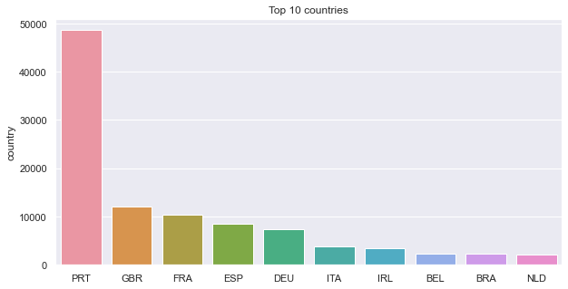

```python
country=(df['country'].value_counts()).head(10)
plt.figure(figsize=(10,5))
sns.barplot(x=country.index,y=country)
plt.title("Top 10 countries");
```